title: “DIMENSIONALITY REDUCTION” author: “KIPLANGAT-DAVID” date: “February 1, 2022” output: html_document

##RESEARCH QUESTION##

Carrefour Kenya and are currently undertaking a project that will inform the marketing department on the most relevant marketing strategies that will result in the highest no. of sales (total price including tax).This project is aimed at doing analysis on the dataset provided by carrefour and create insights on how to achieve highest sales.

##METRIC FOR SUCCESS##

##THE CONTEXT##

Carre Four is an International chain of retail supemarkets in the world, It was set up in Kenya in the year 2016 and has been performing well over the years.Carrefour ensures customer satisfaction and everyday convenience while offering unbeatable value for money with a vast array of more than 100,000 products, shoppers can purchase items for their every need, whether home electronics or fresh fruits from around the world, to locally produced items. This project is aimed at obtaining important variables (in form of components) which will be useful in creating insights from existing and current trends to develop marketing strategies that will enable the marketing team achieve higher sales.

##EXPERIMENTAL DESIGN##

1. Loading libraries
2. Load data
3. Data cleaning
4. Exploratory analysis
5. Dimension reduction
6. Conclusion
7. Recommendation

##DATA RELEVANCE##

The data we are using for this study was sourced from CarreFour database and is a reflection of current transactions

##1. LIBRARIES##

```r
library(ggplot2)
library(tidyverse)
library(gmodels)
library(ggmosaic)
library(corrplot)
library(caret)
library(rpart)
library(rpart.plot)
library(fpc)
library(data.table)
library(plyr)
library(dplyr)
library(cluster)
library(factoextra)
library(flextable)
```

##@. LOAD DATA##

```r
df <- read.csv('http://bit.ly/CarreFourDataset')
head(df)
```

```
##    Invoice.ID Branch Customer.type Gender           Product.line Unit.price
## 1 750-67-8428      A        Member Female      Health and beauty      74.69
## 2 226-31-3081      C        Normal Female Electronic accessories      15.28
## 3 631-41-3108      A        Normal   Male     Home and lifestyle      46.33
## 4 123-19-1176      A        Member   Male      Health and beauty      58.22
## 5 373-73-7910      A        Normal   Male      Sports and travel      86.31
## 6 699-14-3026      C        Normal   Male Electronic accessories      85.39
##   Quantity     Tax      Date  Time     Payment   cogs gross.margin.percentage
## 1        7 26.1415  1/5/2019 13:08     Ewallet 522.83                4.761905
## 2        5  3.8200  3/8/2019 10:29        Cash  76.40                4.761905
## 3        7 16.2155  3/3/2019 13:23 Credit card 324.31                4.761905
## 4        8 23.2880 1/27/2019 20:33     Ewallet 465.76                4.761905
## 5        7 30.2085  2/8/2019 10:37     Ewallet 604.17                4.761905
## 6        7 29.8865 3/25/2019 18:30     Ewallet 597.73                4.761905
##   gross.income Rating    Total
## 1      26.1415    9.1 548.9715
## 2       3.8200    9.6  80.2200
## 3      16.2155    7.4 340.5255
## 4      23.2880    8.4 489.0480
## 5      30.2085    5.3 634.3785
## 6      29.8865    4.1 627.6165
```

Check dimension of dataset

```r
dim(df)
```

```
## [1] 1000   16
```

Our data has 1000 observations and 16 variables

Now we check faeture names

```r
names(df)
```

```
##  [1] "Invoice.ID"              "Branch"
##  [3] "Customer.type"           "Gender"
##  [5] "Product.line"            "Unit.price"
##  [7] "Quantity"                "Tax"
##  [9] "Date"                    "Time"
## [11] "Payment"                 "cogs"
## [13] "gross.margin.percentage" "gross.income"
## [15] "Rating"                  "Total"
```

##@. DATA CLEANING##

Missing values

```r
sum(is.na(df))
```

```
## [1] 0
```

-There are no missing values

Duplicates

```r
anyDuplicated(df)
```

```
## [1] 0
```

-Duplicates do not exist as well

Data types

```r
columns = colnames(df)
for (column in seq(length(colnames(df)))){
    print(columns[column])
    print(class(df[, column]))
    cat('\n')}
```

```
## [1] "Invoice.ID"
## [1] "character"
##
## [1] "Branch"
## [1] "character"
##
## [1] "Customer.type"
## [1] "character"
##
## [1] "Gender"
## [1] "character"
##
## [1] "Product.line"
## [1] "character"
##
## [1] "Unit.price"
## [1] "numeric"
##
## [1] "Quantity"
## [1] "integer"
##
## [1] "Tax"
## [1] "numeric"
##
## [1] "Date"
## [1] "character"
##
## [1] "Time"
## [1] "character"
##
## [1] "Payment"
## [1] "character"
##
## [1] "cogs"
## [1] "numeric"
##
## [1] "gross.margin.percentage"
## [1] "numeric"
##
## [1] "gross.income"
## [1] "numeric"
##
## [1] "Rating"
## [1] "numeric"
##
## [1] "Total"
## [1] "numeric"
```

- our datatypes are numeric, integer and character. We will make our dataset numeric because PCA works on numeric variables

Drop invoice_id,date and time columns

```r
#drop
df <- within(df,rm('Invoice.ID','Date','Time'))
```

```r
head(df)
```

```
##   Branch Customer.type Gender           Product.line Unit.price Quantity
## 1      A        Member Female      Health and beauty      74.69        7
## 2      C        Normal Female Electronic accessories      15.28        5
## 3      A        Normal   Male     Home and lifestyle      46.33        7
## 4      A        Member   Male      Health and beauty      58.22        8
## 5      A        Normal   Male      Sports and travel      86.31        7
## 6      C        Normal   Male Electronic accessories      85.39        7
##       Tax     Payment   cogs gross.margin.percentage gross.income Rating
## 1 26.1415     Ewallet 522.83                4.761905      26.1415    9.1
## 2  3.8200        Cash  76.40                4.761905       3.8200    9.6
## 3 16.2155 Credit card 324.31                4.761905      16.2155    7.4
## 4 23.2880     Ewallet 465.76                4.761905      23.2880    8.4
## 5 30.2085     Ewallet 604.17                4.761905      30.2085    5.3
## 6 29.8865     Ewallet 597.73                4.761905      29.8865    4.1
##      Total
## 1 548.9715
## 2  80.2200
## 3 340.5255
## 4 489.0480
## 5 634.3785
## 6 627.6165
```

Encode categorical variables

```r
#select list of categorical variables,df1
df1 <- df[,c(1,2,3,4,8)]#categorical
#make a subset of non-categorical variables,df2
df2 <- df[,c(5,6,7,9,10,11,12,13)]
```

Now encode categorical variables

```r
dmy <- dummyVars(" ~ .", data = df1, fullRank = T)
df3 <- data.frame(predict(dmy, newdata = df1))
```

Combine the encoded with the original numeric variables

```r
data <- cbind(df3,df2)
```

##4. DIMENSION REDUCTION##

We will apply Principal Component Analysis (PCA)

PCA is a method of obtaining important variables (in form of components) from a large set of variables available in a data set. It extracts low dimensional set of features by taking a projection of irrelevant dimensions from a high dimensional data set with a motive to capture as much information as possible -The base R function prcomp() is used to perform PCA

```r
# Apply PCA using prcomp function

my_pca <- prcomp(data, scale = F,
                center = TRUE, retx = T)
names(my_pca)
```

```
## [1] "sdev"     "rotation" "center"   "scale"    "x"
```

“sdev” “rotation” “center” “scale” “x” The prcomp() useful measures:

1. center and scale refers to respective mean and standard deviation of the variables that are used for normalization prior to implementing PCA
2. The rotation measure provides the principal component loading. Each column of rotation matrix contains the principal component loading vector

```r
# Summary
summary(my_pca)
```

```
## Importance of components:
##                             PC1      PC2     PC3     PC4    PC5    PC6    PC7
## Standard deviation     340.3819 20.53217 1.71990 1.24648 0.5801 0.5763 0.5017
## Proportion of Variance   0.9963  0.00363 0.00003 0.00001 0.0000 0.0000 0.0000
## Cumulative Proportion    0.9963  0.99994 0.99997 0.99998 1.0000 1.0000 1.0000
##                           PC8    PC9   PC10   PC11   PC12   PC13   PC14   PC15
## Standard deviation     0.4907 0.4187 0.4105 0.4023 0.3914 0.3382 0.3273 0.1671
## Proportion of Variance 0.0000 0.0000 0.0000 0.0000 0.0000 0.0000 0.0000 0.0000
## Cumulative Proportion  1.0000 1.0000 1.0000 1.0000 1.0000 1.0000 1.0000 1.0000
##                             PC16      PC17      PC18      PC19
## Standard deviation     2.118e-13 8.144e-15 7.661e-16 1.166e-30
## Proportion of Variance 0.000e+00 0.000e+00 0.000e+00 0.000e+00
## Cumulative Proportion  1.000e+00 1.000e+00 1.000e+00 1.000e+00
```

See the principal components

```r
dim(my_pca$x)
```

```
## [1] 1000   19
```

```r
my_pca$x
```

[output not shown]

[output cut: 3989 more lines]

-We have 19 pricipal components

Let’s plot the resultant principal components.

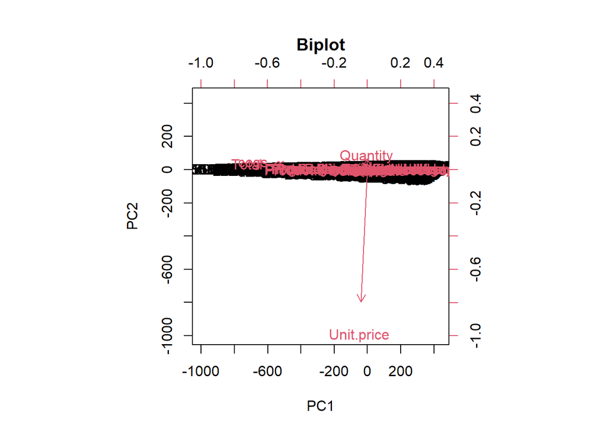

```r
# Plotting the resultant principal components
# The parameter scale = 0 ensures that arrows
# are scaled to represent the loadings
biplot(my_pca, main = "Biplot", scale = 0)
```

-2nd principal component correspond to the unit.price

Compute standard deviation

```r
my_pca$sdev
```

```
##  [1] 3.403819e+02 2.053217e+01 1.719895e+00 1.246483e+00 5.800771e-01
##  [6] 5.763383e-01 5.017009e-01 4.907244e-01 4.186708e-01 4.104856e-01
## [11] 4.022586e-01 3.913561e-01 3.381771e-01 3.272643e-01 1.670828e-01
## [16] 2.118331e-13 8.144043e-15 7.661006e-16 1.166110e-30
```

-The first 4 principal components has their standard deviations greater than 1. This shows that these components explain the maximum variance and therefore retain as much information as possible.

Lets compute proportion of variance explained by each component -we will achieve this by dividing the variance by sum of total variance.

```r
# Compute variance
my_pca.var <- my_pca$sdev ^ 2
#proportion of variance
propvar <- my_pca.var/sum(my_pca.var)
propvar
```

```
##  [1] 9.963182e-01 3.625224e-03 2.543719e-05 1.336097e-05 2.893588e-06
##  [6] 2.856407e-06 2.164487e-06 2.070811e-06 1.507337e-06 1.448975e-06
## [11] 1.391477e-06 1.317072e-06 9.834532e-07 9.210061e-07 2.400648e-07
## [16] 3.858805e-31 5.703552e-34 5.047041e-36 1.169350e-65
```

-first principal component explains 99.6% variance. -Second component explains 0.36% variance and so on

##Scree Plot##

A scree plot is used to access components or factors which explains the most of variability in the data. It will help us decide how many components we should select for modeling stage

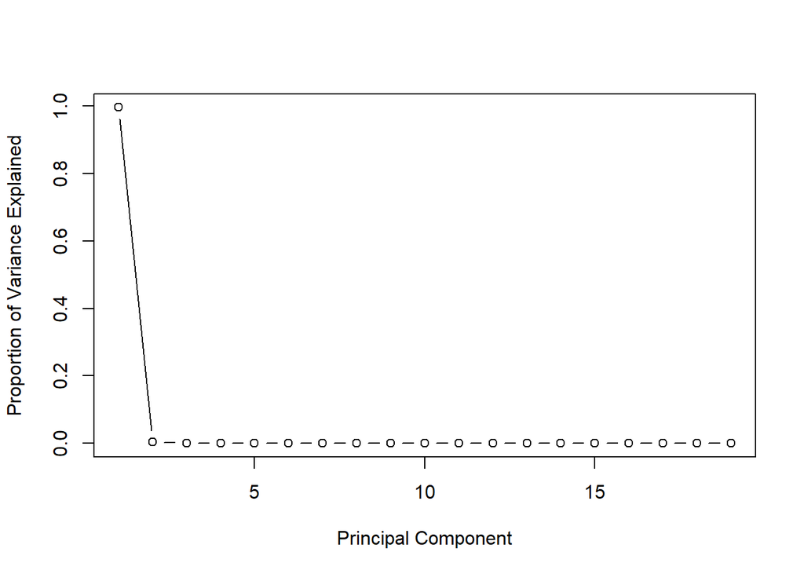

```r
plot(propvar, xlab = "Principal Component",
             ylab = "Proportion of Variance Explained",
             type = "b")
```

##Cumulative Scree Plot##

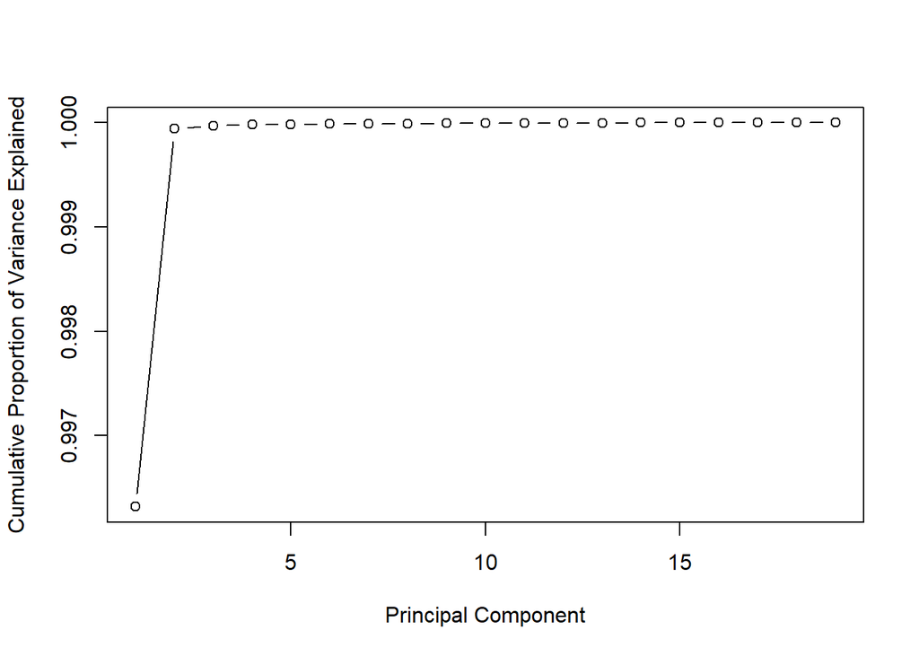

```r
 plot(cumsum(propvar), xlab = "Principal Component",
              ylab = "Cumulative Proportion of Variance Explained",
            type = "b")
```

##RECOMMENDATION##

Apply other dimension reduction methods such as t-Distributed Stochastic Neighbor Embeddding and compare the results